# DS Assignment 2

Ankit

20/10/2021

```r
library(tidyverse)  #Import Library
```

# 1. Covid-19 Data

## 1.1

```r
africa <- read.delim("covid/countries-africa.csv.bz2")  #Reading the Africa File
#The function read.delim() is used for reading a datafile here. Thus, we see that the dataset 'countries-africa.csv.bz2' contains

dim(africa)
```

```
## [1] 58  5
```

```r
africa %>% head()
```

```
##   rank                          country  population             year
## 1    1                          Nigeria 206,139,589             2020
## 2    2                         Ethiopia 109,224,414             2018
## 3    3 Democratic Republic of the Congo 102,561,403     July 1, 2020
## 4    4                            Egypt 101,334,404 December 8, 2020
## 5    5                     South Africa  59,956,820 December 1, 2020
## 6    6                         Tanzania  59,734,218             2020
##                            source
## 1                 Worldometers[3]
## 2 UN population projections[4][5]
## 3      National annual projection
## 4       National population clock
## 5               Official estimate
## 6                    Worldometers
```

```r
africaCountry <- africa %>% distinct(country) %>% count() #Unique african Countries
```

Total unique African countries in the data set is 58

### 1.1.2 Collect all the names of covid data files covid-global into a character vector. How many files are there?

```r
files <- list.files(path = "E:/UW MSIM Course materials/DS 1 Material/DS Assignment 2/covid",pattern = "\\bcovid")       #getting list of all the covid files
print(files)
```

```
##  [1] "covid-global_01-01-2021.csv.bz2" "covid-global_02-01-2020.csv.bz2"
##  [3] "covid-global_02-01-2021.csv.bz2" "covid-global_03-01-2020.csv.bz2"
##  [5] "covid-global_03-01-2021.csv.bz2" "covid-global_04-01-2020.csv.bz2"
##  [7] "covid-global_04-01-2021.csv.bz2" "covid-global_05-01-2020.csv.bz2"
##  [9] "covid-global_05-01-2021.csv.bz2" "covid-global_06-01-2020.csv.bz2"
## [11] "covid-global_06-01-2021.csv.bz2" "covid-global_07-01-2020.csv.bz2"
## [13] "covid-global_07-01-2021.csv.bz2" "covid-global_08-01-2020.csv.bz2"
## [15] "covid-global_08-01-2021.csv.bz2" "covid-global_09-01-2020.csv.bz2"
## [17] "covid-global_09-01-2021.csv.bz2" "covid-global_10-01-2020.csv.bz2"
## [19] "covid-global_10-01-2021.csv.bz2" "covid-global_11-01-2020.csv.bz2"
## [21] "covid-global_12-01-2020.csv.bz2"
```

```r
countFiles <- length(files)
```

Total number of files with name starting from “covid-global” is 21

```r
oct_file <- read.delim("E:/UW MSIM Course materials/DS 1 Material/DS Assignment 2/covid/covid-global_10-01-2020.csv.bz2")

oct_file %>% dim()
```

```
## [1] 3981   14
```

```r
names(oct_file)  #Names of the columns
```

```
##  [1] "FIPS"                "Admin2"              "Province_State"
##  [4] "Country_Region"      "Last_Update"         "Lat"
##  [7] "Long_"               "Confirmed"           "Deaths"
## [10] "Recovered"           "Active"              "Combined_Key"
## [13] "Incidence_Rate"      "Case.Fatality_Ratio"
```

### 1.1.4 How many African countries in the African Country list do you find in the covid data? Do

not attempt to adjust the names for now.

```r
africa_countries <- length(which(africa$country %in% oct_file$Country_Region)) #Arican Countries in the global data
africa_countries
```

```
## [1] 49
```

Total number of African countries in global data is 49

### 1.1.5 Which African countries are not matched in the COVID data? Again, do not adjust the names

```r
africa %>% filter(!(africa$country %in% oct_file$Country_Region)) #Countries which were not in the Global data
```

```
##   rank                                           country  population
## 1    3                  Democratic Republic of the Congo 102,561,403
## 2   16                                       Ivory Coast  22,671,331
## 3   39                             Republic of the Congo   3,697,490
## 4   NA                                 RÃ©union (France)     840,974
## 5   NA                                    Western Sahara     510,713
## 6   52                                        Cape Verde     491,875
## 7   NA                                  Mayotte (France)     212,600
## 8   53                          SÃ£o TomÃ© and PrÃncipe     201,784
## 9   NA Saint Helena, Ascension and Tristan da Cunha (UK)       5,633
##                year                                        source
## 1      July 1, 2020                    National annual projection
## 2      May 15, 2014                Preliminary 2014 census result
## 3    April 28, 2007                            2007 census result
## 4   January 1, 2013                             Official estimate
## 5 September 2, 2014                Preliminary 2014 census result
## 6     June 16, 2010 Final 2010 census result[permanent dead link]
## 7   August 21, 2012                            2012 census result
## 8              2018                             Official estimate
## 9         June 2016                            2016 census result
```

### 1.1.6 Why should we care more about these three countries and less about other entities?

80% of the population is covered in the top three countries and as per the Parito principal, we can get all the information with the top 80% of the data.

Another way of looking at this answer is We should care more about Congo (DR and R) and Ivory coast as they belong to the African continent or on the African coast. Also,Congo (DR and R) are conflicted regions and are under continuous military conflicts. We should care less about other entities as they do not belong to the African region and analyzing their data may affect our results.

### 1.1.8 Amend the list of African countries in a way that you can extract all the necessary African countries (you may leave out the islands/territories) from COVID data. Demonstrate that it works.

```r
#Created three separate vectors with the new names of the countries
#Append in the existing file using rbind function.

v1 <- c(3,"Congo (Brazzaville)",102561403, "July 1, 2020", "National annual projection")
v2 <- c(39,"Congo (Kinshasa)",3697490, "April 28, 2007", "2007 census result")
v3 <- c(16,"Cote d'Ivoire",22671331, "May 15, 2014", "Preliminary 2014 census result")

africa_new <- rbind(africa,v1)
africa_new <- rbind(africa_new,v2)
africa_new <- rbind(africa_new,v3)

tail(africa_new)
```

```
##    rank                                           country population
## 56   53                          SÃ£o TomÃ© and PrÃncipe    201,784
## 57   54                                        Seychelles     90,945
## 58 <NA> Saint Helena, Ascension and Tristan da Cunha (UK)      5,633
## 59    3                               Congo (Brazzaville)  102561403
## 60   39                                  Congo (Kinshasa)    3697490
## 61   16                                     Cote d'Ivoire   22671331
##               year                         source
## 56            2018              Official estimate
## 57 August 26, 2010       Final 2010 census result
## 58       June 2016             2016 census result
## 59    July 1, 2020     National annual projection
## 60  April 28, 2007             2007 census result
## 61    May 15, 2014 Preliminary 2014 census result
```

```r
#Checking whether the countries are in the overall global dataset or not.

oct_file %>% filter(Country_Region %in% africa_new$country[59:62])
```

```
##   FIPS Admin2 Province_State      Country_Region          Last_Update     Lat
## 1   NA                       Congo (Brazzaville) 2020-10-02T04:23:51Z -0.2280
## 2   NA                          Congo (Kinshasa) 2020-10-02T04:23:51Z -4.0383
## 3   NA                             Cote d'Ivoire 2020-10-02T04:23:51Z  7.5400
##     Long_ Confirmed Deaths Recovered Active        Combined_Key Incidence_Rate
## 1 15.8277      5089     89      3887   1113 Congo (Brazzaville)       92.22391
## 2 21.7587     10685    272     10165    248    Congo (Kinshasa)       11.93036
## 3 -5.5471     19755    120     19320    315       Cote d'Ivoire       74.89117
##   Case.Fatality_Ratio
## 1           1.7488701
## 2           2.5456247
## 3           0.6074412
```

## 1.2 Load and merge all datasets

### 1.2.1 Extract Date parts from the file names

```r
  as.Date(gsub(".*[_]|[.].*", "\\1", files[1]),format = "%m-%d-%Y") #Extracting the date part from the file names.
```

```
## [1] "2021-01-01"
```

### 1.2.2 Merging all the file to create one final dataframe

```r
Final <- NULL
for(i in files){  #for loop starts
  url <- sprintf("E:/UW MSIM Course materials/DS 1 Material/DS Assignment 2/covid/%s",i)
  mega_file <- read.delim(url)

  Date <- as.Date(gsub(".*[_]|[.].*", "\\1", i),format = "%m-%d-%Y")


  colnames(mega_file)[which(names(mega_file) == "Country.Region")] <- "Country_Region" #Changing the country.region as to make the schema nenutral.
  if("Country_Region" %in% colnames(mega_file)){    #If loop starts
    local <- mega_file %>%
      mutate(Year=lubridate::year(Date),Month=lubridate::month(Date)) %>%
      filter(mega_file$Country_Region %in% africa_new$country) %>%
      select(Country_Region,Deaths,Year,Month)

  }
  Final <- rbind(Final,local)  #appending to the null df created above

}  #for loop ends
dim(Final)
```

```
## [1] 986   4
```

# 1.3 Time Series

### 1.3.1

```r
africa_new_1 <- africa_new %>% select(country,population) #Selecting two columns from the dataset
Final <- merge(Final, africa_new_1, by.x="Country_Region", by.y="country",all.x=TRUE) #Merging final dataset with African dataset to get population and Death rate.
head(Final)
```

```
##   Country_Region Deaths Year Month population
## 1        Algeria   2762 2021     1 43,000,420
## 2        Algeria   5302 2021     9 43,000,420
## 3        Algeria   3261 2021     5 43,000,420
## 4        Algeria   1518 2020     9 43,000,420
## 5        Algeria    453 2020     5 43,000,420
## 6        Algeria   4291 2021     8 43,000,420
```

### 1.3.2 Compute the death rate: number of deaths per 1M population

- First we converted population to int as it was in char.
- For the conversion, first we replaced “,” and then applied as_numeric function.
- Then created column “death_rate” by calculation deaths/population for 1M population.
- Furthermore, we applied filter on October and then applied grouby to get number of deaths per 1M population.

```r
Final$population <-  gsub(",","",Final$population)
Final$population <- as.numeric(Final$population,na.rm=TRUE)
Final <- Final %>% mutate(death_rate = round(Deaths*1000000/population,2))
Final_1 <- Final %>% filter(Year == 2021 & Month == 10) %>% group_by(Country_Region) %>% summarize(Death_rate = round(death_rate/n(),2))

Final_1 %>% head()
```

```
## # A tibble: 6 x 2
##   Country_Region Death_rate
##   <chr>               <dbl>
## 1 Algeria            135.
## 2 Angola              64.3
## 3 Benin               15.9
## 4 Botswana          1169.
## 5 Burkina Faso         9.97
## 6 Burundi              3.87
```

### 1.3.3 10 countries with the largest death rate

- Arranged the data by descending order by death rate to get 10 countries with the largetst death rate.

```r
Final_1_top <- Final_1 %>% arrange(desc(Death_rate)) %>% head(10)
Final_1_top
```

```
## # A tibble: 10 x 2
##    Country_Region Death_rate
##    <chr>               <dbl>
##  1 Tunisia             2267.
##  2 Namibia             1541.
##  3 South Africa        1463.
##  4 Seychelles          1232.
##  5 Botswana            1169.
##  6 Eswatini            1093.
##  7 Libya                880.
##  8 Morocco              386.
##  9 Zimbabwe             354.
## 10 Lesotho              315.
```

### 1.3.4 Death rate for top 10 countries.

- First get the proper data for the top 10 countries by filtering it.
- Then plotted a graph while creating a date variable to make the graph consistent.
- Used line graph to show death rate of all the regions.
- Used scale_x_date to reduced the scale of the x axis to 3 months for better representation of graph.
- Applied Xlab and Ylab to properly label the graph

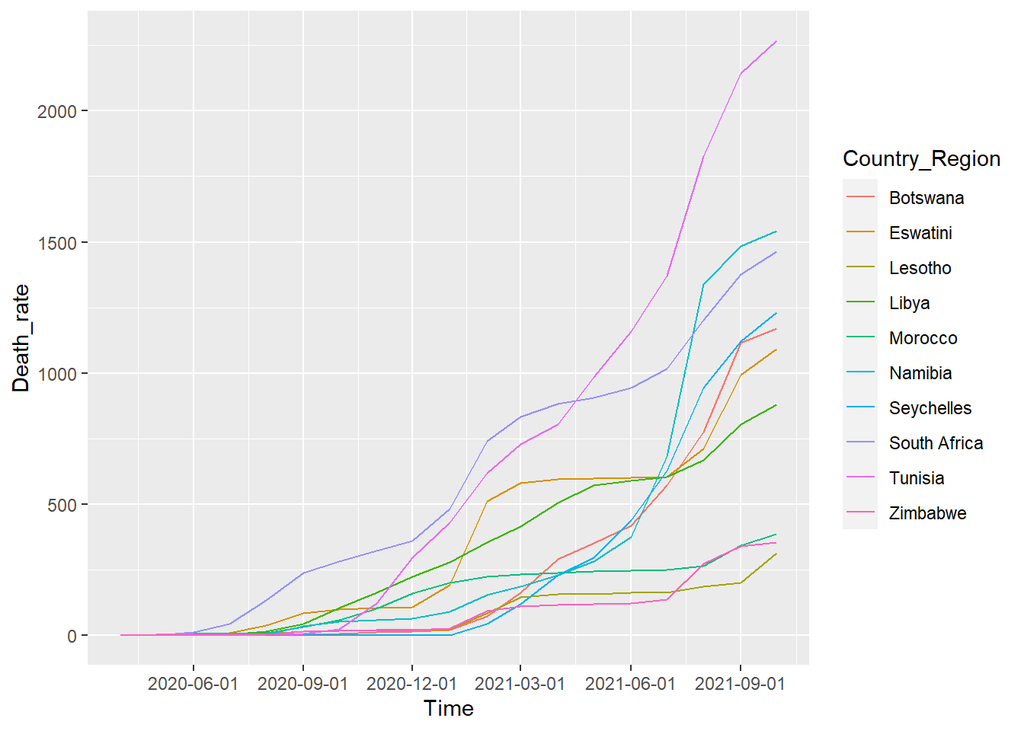

```r
Final1 <- Final %>% filter(Country_Region %in% Final_1_top$Country_Region)
ggplot(Final1, aes(x=as.Date(paste0(Year,"-",Month,"-","01"),"%Y-%m-%d"),y=death_rate,col=Country_Region)) + geom_line() +scale_x_date(date_breaks = "3 month") +xlab('Time') + ylab("Death_rate")
```

#### 1.3.5 Month wise death growth rate grown from 10 countries

- Created a new column “YearMonth” for easy use of lag function.
- Created another new new column “Monthly_death” where I used lag function to create monthly death which was ordered by “YearMonth”.
- Created 3rd new column which was calculated by monthly_death divided by population to get monthly death rate.
- Plotted another graph with X axis and Monthly death rate on Y axis.
- Used scale_x_date to reduced the scale of the x axis to 3 months for better representation of graph.
- Applied Xlab and Ylab to properly label the graph

```r
Final2 <- Final1 %>%
  mutate(Yearmonth = as.Date(paste0(Year,"-",Month,"-","01"),"%Y-%m-%d")) %>%
  group_by(Country_Region) %>%
  mutate(monthly_death = Deaths - lag(Deaths,default = 0,order_by=Yearmonth)) %>%  arrange(Country_Region,Year, Month) %>% mutate(Monthly_Death_rate = round(monthly_death*1000000/population,2))


Final2
```

```
## # A tibble: 188 x 9
## # Groups:   Country_Region [10]
##    Country_Region Deaths  Year Month population death_rate Yearmonth
##    <chr>           <int> <dbl> <dbl>      <dbl>      <dbl> <date>
##  1 Botswana            1  2020     4    2024904       0.49 2020-04-01
##  2 Botswana            1  2020     5    2024904       0.49 2020-05-01
##  3 Botswana            1  2020     6    2024904       0.49 2020-06-01
##  4 Botswana            1  2020     7    2024904       0.49 2020-07-01
##  5 Botswana            2  2020     8    2024904       0.99 2020-08-01
##  6 Botswana            6  2020     9    2024904       2.96 2020-09-01
##  7 Botswana           16  2020    10    2024904       7.9  2020-10-01
##  8 Botswana           24  2020    11    2024904      11.8  2020-11-01
##  9 Botswana           34  2020    12    2024904      16.8  2020-12-01
## 10 Botswana           42  2021     1    2024904      20.7  2021-01-01
## # ... with 178 more rows, and 2 more variables: monthly_death <dbl>,
## #   Monthly_Death_rate <dbl>
```

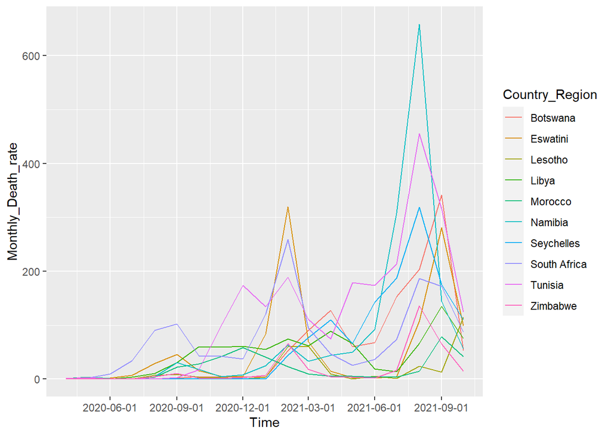

```r
ggplot(Final2, aes(x=Yearmonth,y=Monthly_Death_rate,col=Country_Region)) + geom_line() +scale_x_date(date_breaks = "3 month") +xlab('Time') + ylab("Monthly_Death_rate")
```

### 1.3.6

```r
Final2 %>% arrange(desc(Monthly_Death_rate))
```

```
## # A tibble: 188 x 9
## # Groups:   Country_Region [10]
##    Country_Region Deaths  Year Month population death_rate Yearmonth
##    <chr>           <int> <dbl> <dbl>      <dbl>      <dbl> <date>
##  1 Namibia          3057  2021     8    2280700      1340. 2021-08-01
##  2 Tunisia         20067  2021     8   10982754      1827. 2021-08-01
##  3 Botswana         2261  2021     9    2024904      1117. 2021-09-01
##  4 Eswatini          574  2021     2    1119375       513. 2021-02-01
##  5 Seychelles         86  2021     8      90945       946. 2021-08-01
##  6 Tunisia         23538  2021     9   10982754      2143. 2021-09-01
##  7 Namibia          1556  2021     7    2280700       682. 2021-07-01
##  8 Eswatini         1112  2021     9    1119375       993. 2021-09-01
##  9 South Africa    44399  2021     2   59956820       741. 2021-02-01
## 10 Tunisia         15065  2021     7   10982754      1372. 2021-07-01
## # ... with 178 more rows, and 2 more variables: monthly_death <dbl>,
## #   Monthly_Death_rate <dbl>
```

Namibia has experienced the highest peak in the new monthly deaths. It happened in August 2021. We can see 2 covid waves in the plot.

- First one around early 2021 between Feb and March.
- Second one between July 2021 and August 2021.

# 1.4

### 1.4.1 Where would the US be on the top-10 list of African countries?

USA would be on the Second position of the top 10 list of African countries(Google) with the death rate of 2,223.04 per million. Tunisia on the other hand has a death rate of 2267.28 per million which is on the first place and Namibia with a death rate of 1540.76 per million

### 1.4.2 What do you think about reliability of these data?

Although the Google data suggests that South Africa has a greater death rate than Tunisia, Tunisia has been claimed to have a higher death rate in the analysis. Egypt is ranked third, although it does not appear in our top ten countries. As a result, I believe the data is unreliable.

### How much time (hours) did you spend on this problem set?

It took me 18 hrs to complete this assignment.